# Where RACs fall on new shoes

The complete model on the second collection of 631 shoes, the comparison with the original 386, and the goodness of fit Micha asked for. Prepared for Micha Mandel, FSI revision FSI-D-26-01184.

9 November 2026 | Branch `feature/new-shoes-finish` | Every number comes from the result files in `docs/`, which cite their sources.

## In six points

What this section is for: the whole report in six sentences.

Micha asked for two things at the meeting of 5 November: (1) fit the model of the paper on the second collection, with the same standardization of the shoe; (2) test whether the surface fitted on the original shoes predicts where RACs fall on the new shoes, by summing p·S with the random effect at 0 over parts of the shoe (Naomi's 14 areas, or a grid of 10 to 20 cells).

1. **Request 1 is done.** The model runs on all 631 new shoes. RAC intensity is again far from uniform, also when whole shoes are resampled (p < 10<sup>−16</sup>). The original results reproduce exactly.
2. **Request 2 is done.** The surface fitted on the original shoes does not transfer exactly: X² = 298 on Naomi's 14 areas against a noise floor of 49, p < 0.001. A simulation confirms that the test holds its size. The 2022 regional model is rejected too.
3. **Why it misfits.** New RACs are spread more evenly than the surface says (calibration slope 0.70), and they shift along the shoe: more toward the heel and the rear midfoot, fewer in the central forefoot (Figs. 3–5).
4. **Our model against the 2022 model.** On the new shoes our model has the largest X² on every partition: the 2022 model, and even a simple step model on 15 cells, fit the part counts better. On Naomi's 14 areas the difference is clear; on Micha's grids it is borderline (it excludes 0 for the fitted surfaces, and includes 0 on two of three grids once the estimation error of the original fits is added). Per RAC, the log score shows no difference. In short: our model shows no predictive advantage over the 2022 model on new shoes.
5. **Robust.** Same scale and same shoe size in both collections (checked on the soles printed in both); non-uniformity survives a shoe bootstrap in both collections; the rejection is not an artefact of the knots.
6. **Provisional, and for Micha to decide.** The validation set excludes 67 likely reprints of original shoes and 22 uncertain ones; that list is not yet confirmed, and the fit has no per-shoe offset. Either may change the numbers; we do not expect it to change the conclusions. Open decisions: the offset, the knot sensitivity analysis, the reply to Reviewer 1.

## Data

What this section is for: how many shoes and RACs each collection has, and which new shoes were left out and why.

|  | Original collection (paper) | New collection |
| --- | --- | --- |
| Shoes | 387 (386 with RACs) | 631 (all with RACs) |
| RACs | 13,287 | 20,013 |
| Image frame | 307 × 395 px | 255 × 367 px; the same scale, 300 px per unit, after dividing the new coordinates by 2 |
| Used in the goodness of fit | all 386 (to fit the model) | 478 shoes, 13,636 RACs (the primary set) |

**The collections overlap.** The team said in the meeting that they don't; the data disagree. 67 new shoes are very likely reprints of original shoes and 22 more are uncertain, together 15.8% of the new RACs. Consecutive new ids map onto consecutive original ids far more often than chance (16 of 57 pairs, where about 0.3 would be expected). The evidence comes from a screen of 121 flagged shoes, not of all new shoes.

**Please confirm with Sarena or Yoram.** The primary set of 478 excludes the likely and the uncertain reprints and the prints that fail an automatic quality rule; 31 flagged candidates were not reviewed by eye.

### Why the goodness of fit uses 478 of the 631 new shoes

[output not shown]

The choice does not change the conclusion. Goodness of fit of our model on Naomi's 14 areas, for every shoe set:

| Shoe set | Shoes | X² | Noise floor | p |
| --- | --- | --- | --- | --- |
| **Primary (used in the report)** | **478** | **298** | 49 | < 0.001 |
| All new shoes | 631 | 504 | 62 | < 0.001 |
| Only the likely reprints removed | 495 | 294 | 50 | < 0.001 |
| Reprints removed, no quality rule | 542 | 398 | 54 | < 0.001 |
| Also the 31 unreviewed candidates removed | 453 | 263 | 47 | < 0.001 |

With all 631 shoes the misfit is larger, so the primary set is the cautious choice. The set is provisional until the reprint list is confirmed. Numbers from `processed_data/validation/new/part2_tests_new.csv`.

## The two maps, original and new

What this section is for: the final maps of our model on each collection, and how to compare them fairly.

These are the final maps of our model: the RAC intensity at each pixel of the standardized shoe, with the random effect set to 0. The toe is at the top, the heel at the bottom.

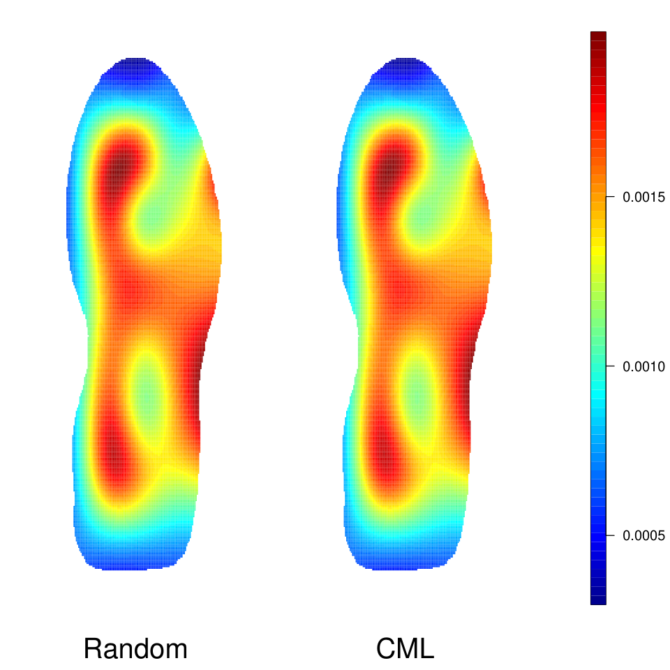

**Fig. 1a. Original shoes, 387 (386 with RACs).** Random effects (left) and conditional maximum likelihood, CML (right). `model_images/pixel_inten_JASAup.pdf`

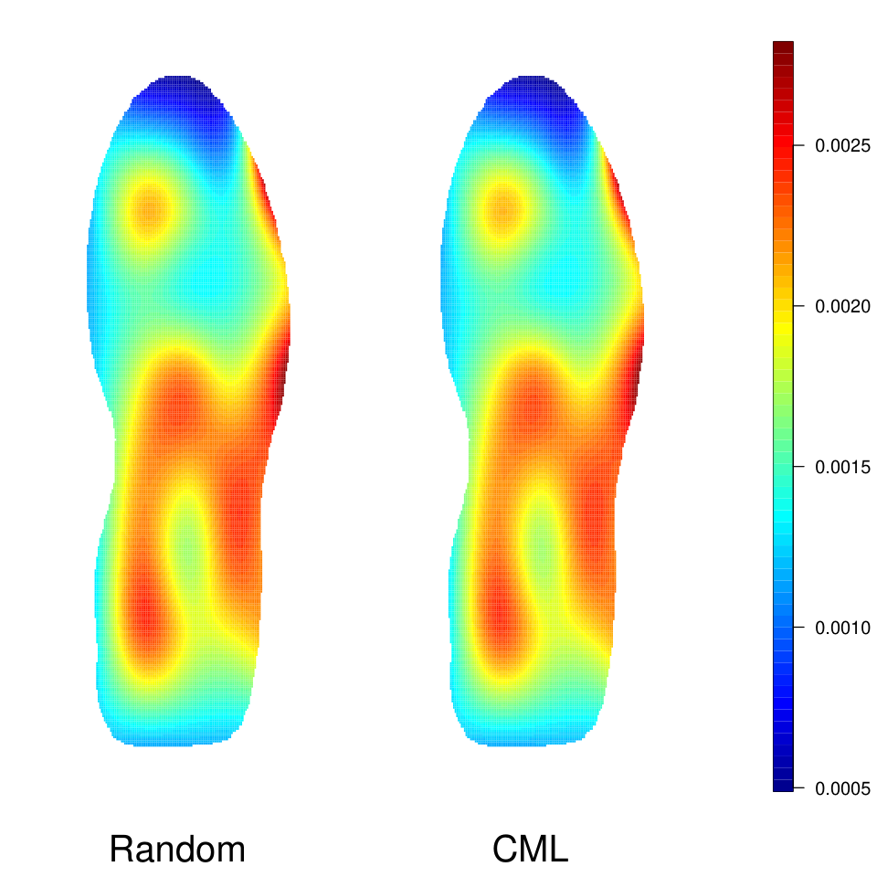

**Fig. 1b. New shoes, 631.** Random effects (left) and CML (right). `model_images/new/pixel_inten_JASAup_new.pdf`

Random effects and CML agree within about 2% on both collections, so neither map depends on the estimation method.

**Read the shapes, not the colours.** Each map has its own colour scale: the original one runs up to about 0.0019 and the new one up to about 0.0028. The rainbow palette turns a 20% change into a jump from yellow to red. The levels of the two maps are not comparable: a map with the random effect at 0 shows the median shoe, not the mean, so its level depends on σ² and on the per-shoe offset that the fit lacks, and both differ between the fits. The observed RAC levels differ by only 6%.

### What the maps show

| Region (y from heel 0 to toe 1, as on the axes of Fig. A1; Figs. 2 and A2 use y − 0.5) | Original | New |
| --- | --- | --- |
| Forefoot, left side (y ≈ 0.75) | **Highest** | A small hot spot; the rest moderate |
| Forefoot, right edge | High | A narrow stripe in the map that the data do not show (a spline edge effect; data, shape only: 1.07, 95% CI 0.90–1.26) |
| Right edge, heel to midfoot (y ≈ 0.4) | **Highest**, with the forefoot | High |
| Top of the midfoot (y ≈ 0.5) | High | **Highest** among the broad regions (data, shape only: 1.25 times original, 95% CI 1.10–1.42; the map shows only 1.10) |
| Heel, left side (y ≈ 0.3) | High | High |
| Centre of the heel (y ≈ 0.35) | Low | Low |
| Toe tip and heel edge | Lowest | Lowest |

### The shapes compared properly

Figure 2 removes the colour-scale problem. It divides each collection's map by its own overall RAC density, so only the *shape* is compared: red means the new shoes have relatively more RACs there, blue relatively fewer, white the same. Both fits use the same knots here. It shows the comparison four times: from the model and from the raw RAC counts, each with and without the likely reprints. Figure A2 (appendix) shows the two maps on one absolute scale.

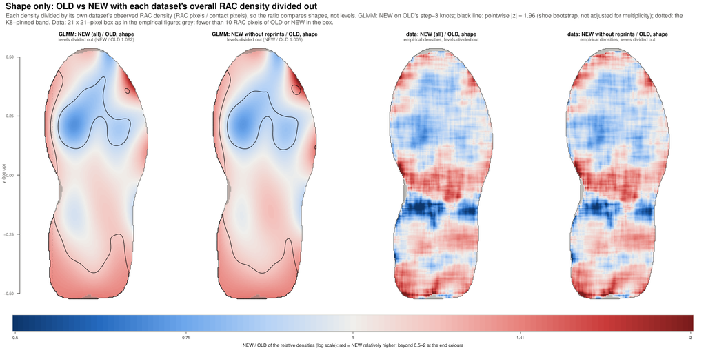

**Fig. 2. Shape only.** New / original after dividing out each collection's overall density: model with all new shoes, model without reprints, data with all new shoes, data without reprints. Black line (model panels only): shoe-bootstrap |z| = 1.96, pointwise, not adjusted for multiplicity; dotted: a band the model holds fixed by construction; grey: fewer than 10 RAC pixels. `model_images/compare/ratio_maps_commonbasis_shape_boot_old_vs_new.pdf`

The two surfaces are close over most of the shoe. Relative to its own total, the new collection is lower in a patch of the forefoot and higher in a band across the top of the midfoot and at the heel bottom (data, shape only: 1.15, 95% CI 1.05–1.28). The red near the right toe is not supported by the data (0.95, 95% CI 0.79–1.15). The raw data also show a lower band at the front of the heel (0.59, 95% CI 0.44–0.83), which the model misses (1.11); a finer basis along the shoe recovers it. The pattern is the same without the reprints.

### Why the outline is the same

Both maps are drawn on the same shoe on purpose. That is the standardization Micha asked for: every RAC is moved from its own shoe onto the original prototype. For each RAC, the pipeline measures its distance from the centre line as a share of its own shoe's half-width on that side at that height, and puts it at the same share on the prototype (`new_x = x · distance_shape / (|x| + horiz_dist)`); y is kept as it is. A RAC halfway between the centre and the edge of its shoe lands halfway between the centre and the edge of the prototype.

The new shoes use the *original* prototype, so both models live in one coordinate system. Without it the maps could not be compared pixel by pixel, and the goodness of fit, which applies the original fit to the new shoes, could not run. The new collection's own prototype is used only to clean its images (stickers and frame lines).

### Why the maps differ

Part of the difference is how the pictures are drawn. Part is real: the test of equal shapes is significant (shoe bootstrap without the reprints, W = 46.7 on 24 terms, p = 0.006 with the F reference, 0.004 with χ²) and the goodness of fit rejects exact transfer. The new/original ratio of the two maps has a median of 1.11 and lies between 0.84 and 1.44 on 90% of the shoe, and the overall level is not significantly different (ratio 1.06, 95% CI 0.93–1.22). The data point to four causes; they cannot tell which one matters most.

[output not shown]

For the paper: this is Reviewer 1's point 4 and the editor's sole-design point. One surface for all shoes is an approximation, and RAC locations depend partly on the sole design.

## Request 1: the model on the new shoes

What this section is for: Micha's first request. The model of the paper, fitted again on the new shoes.

The outline of every shoe is found by an active contour (the "snake"). All 631 outlines were built; images of every shoe were checked by eye three times. Stickers and frame lines were erased; 23 shoes needed a fallback setting and one a different starting ellipse. Quality matches the original shoes.

|  | Original | New |
| --- | --- | --- |
| Case-control rows | 51,849 | 83,090 |
| GLMM σ² (without the per-shoe offset, as in the paper) | 0.960 | 0.756 |
| Wald, all 24 spatial terms = 0, model-based | W = 427.8* | **W = 585.9, p < 10<sup>−16</sup>** |
| CML Wald, exact fit, model-based | 420.7 | 576.0 |
| CML Wald, Efron approximation: model-based (cluster-robust) | 394.2 (234.4) | 580.9 (329.0) |

* With the variance from lme4's RX matrix; the Hessian gives 428.7. The paper should state which.

On the new collection, RAC intensity is again far from uniform. W grows with the number of RACs, so it should not be compared between the collections. A test that allows any dependence within a shoe is in "Robustness checks".

**Reproducibility.** After every step the original pipeline still reproduces the committed files exactly, and a final rerun from scratch of the whole original pipeline and of the new outlines gave identical files.

## Request 2: goodness of fit on the new shoes

What this section is for: Micha's second request. Does the model fitted on the original shoes predict where the RACs fall on the new shoes?

As Micha asked: for each new shoe, p·S is summed over each part of the shoe, with our model fitted on the original shoes and the random effect at 0, and scaled to the shoe's observed number of RACs. The parts are Naomi's 14 areas and grids of 10, 15 and 20 cells. The test statistic is Pearson's X² over the parts. Its reference distribution comes from a two-sample shoe bootstrap (B = 2,000) that resamples both the original shoes (refitting the model) and the new shoes, so it includes the estimation error of the original fit, overdispersion and the differences between shoes. A naive χ² with fixed expected counts would reject a correct model about 80% of the time.

**Terms used below and in the figures.**

- **Our model** = the continuous model of the paper (random effects, splines), fitted on the original shoes and used unchanged to predict the new ones. The figures call it "Our model"; "Our model, CML estimate" is the same model estimated by conditional maximum likelihood.
- **2022 model** = Naomi's model of 2022: one constant RAC intensity in each of her 14 areas, also fitted on the original shoes.
- **Predicted (expected)** = the number of RACs a model expects in a part of the shoe; **observed** = the number found there.
- **Noise floor** = the mean X² over the 2,000 bootstrap replicates, i.e. what a correct model would typically give here. It is far above the number of parts because of overdispersion and the estimation error.
- **p < 0.001**: no bootstrap replicate reached the observed X², so p = 1/2,001 ≈ 0.0005, the smallest value 2,000 replicates can give.

[output not shown]

**What the test can and cannot say.** Because each shoe's expected counts are scaled to its observed number of RACs, the test is about the *shape* of the surface, not the number of RACs per shoe; heavily marked shoes weigh most. A rejection means "the model is not exactly right *or* the new shoes differ"; the test cannot separate the two. Our model already misfits Naomi's areas on the original shoes it was fitted on (X² 64 over 14 areas, descriptive), in the same direction as on the new shoes (more RACs than predicted at the rear midfoot, fewer in the central forefoot; correlation of the log ratios 0.48), so part of the misfit is the model's own, which the new shoes amplify. A held-out test within the original shoes (fit on part of them, test on the rest) would separate the two; it has not been run. Split by the two sole-design groups found in the new data, the misfit is present in both (X² 230 in a group of 277 shoes, 97.5 in the other 201) with the same heel-to-forefoot gradient, so it is not an effect of the mix of designs alone.

**Provisional.** The shoe set is not frozen (the reprint list awaits confirmation; 31 candidates were not reviewed by eye). The estimation error of the original fit comes from fast refits of the model (fixed effects at the fitted variance), checked against 8 full refits. Every interval treats the new shoes as independent; resampling blocks of consecutive ids, a proxy for pairs of shoes of one wearer, raises φ from 1.74 to 2.20 and the noise floor from 49 to 51–54 (95th percentile 95 to 99–101), far below the observed 298.

### What our model predicts in each area

This is Micha's quantity itself. For each of Naomi's 14 areas, our model gives the share of the new shoes' RACs it expects there (the sum of p·S over all new shoes, random effect 0). Figure 3 puts that next to the share actually observed.

**How to read it, with one area.** Take the left heel area. Left shoe: our model expects 6.0% of all new RACs there. Middle shoe: 7.2% were observed. Right shoe: 7.2 ÷ 6.0 = 1.20, so 20% more RACs than predicted. A perfect model would show the same number on the left and middle shoes, and 1.00 everywhere on the right.

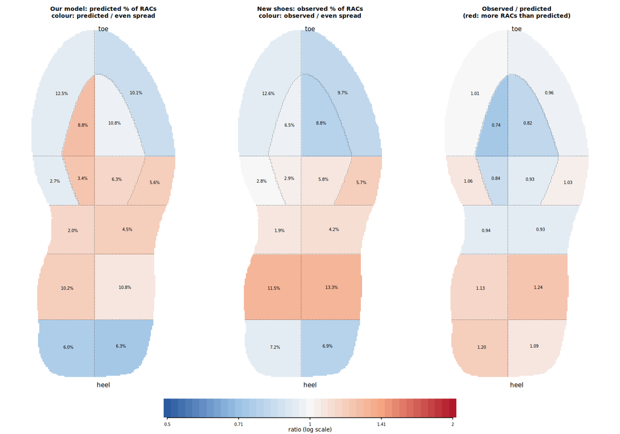

**Fig. 3. Predicted and observed share of RACs per area.** Left: our model, predicted % of the new shoes' RACs in each area; colour = predicted / an even spread of RACs over the sole (red: the model expects more RACs there than an even spread would). Middle: observed % on the new shoes; colour = observed / even spread. Right: observed / predicted, as in Fig. 4. Primary set, 478 shoes, 13,636 RACs. `model_images/validation/new/part2_area_shares_new.pdf`; numbers in `processed_data/validation/new/part2_area_shares_new.csv`

Read across: our model expects 10.2% and 10.8% of the RACs in the two rear-midfoot areas, and the new shoes have 11.5% and 13.3% there. It expects 8.8% and 10.8% in the two central forefoot areas, and the new shoes have 6.5% and 8.8%. At the heel it expects fewer RACs than an even spread (blue, 6.0% and 6.3%), and the new shoes have a little more (7.2% and 6.9%). Nine of the 14 areas are within one percentage point of the prediction; in relative terms the ratios range from 0.74 to 1.24 (Fig. 4).

### Observed / predicted on the shoe

Figure 4 keeps only the ratio, observed ÷ predicted, for our model: on Naomi's 14 areas and on the main 15-cell grid. Red: more RACs than predicted; blue: fewer; white: as predicted. The same map for the 2022 model is Figure A3.

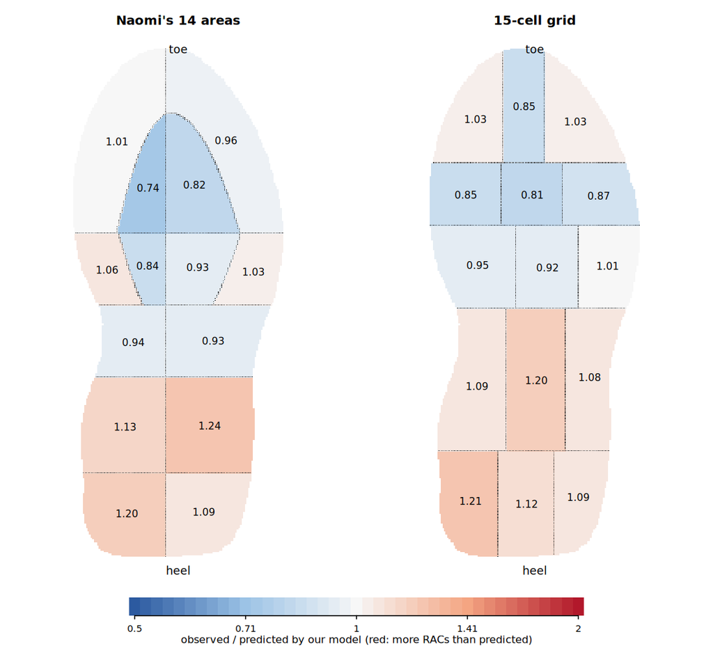

**Fig. 4. Observed / predicted by our model, on the shoe.** Left: Naomi's 14 areas (the right-hand shoe of Fig. 3); right: the main 15-cell grid. Primary set, 478 shoes. `model_images/validation/new/part2_oe_simple_new.pdf`

On Naomi's areas our model is too low at the heel and the rear midfoot (1.09 to 1.24) and too high in the central forefoot (0.74 to 0.84, the three blue central areas). On the 15-cell grid the same pattern appears: the heel bands are red (1.08 to 1.21) and the forefoot band blue (0.81 to 0.87). The 2022 model shows the same pattern a little more weakly (Figure A3).

### Micha's grid: 10 to 20 cells

The cells are cut on the standardized shoe from the original shoes only, before any new number was computed: five bands from heel to toe, each holding 20% of the original contact area, and each band cut across into 2, 3 or 4 cells, giving 10, 15 or 20 cells (15 was chosen in advance as the main grid).

| Cells | Our model: X² (noise floor) | p | 2022 model: X² (noise floor) | p |
| --- | --- | --- | --- | --- |
| 10 | 176 (41) | < 0.001 | 127 (34) | 0.0025 |
| **15 (main)** | **206 (57)** | **< 0.001** | 149 (42) | 0.0015 |
| 20 | 235 (66) | < 0.001 | 163 (50) | 0.001 |

The 10- and 20-cell versions are drawn in Figure A4 (appendix); they show the same pattern.

### The same ratios with intervals

Figure 5 shows the observed / predicted ratios as dots with pointwise 95% intervals. A part whose interval excludes 1 is individually unusual, but with 59 intervals per model a few such parts are expected by chance. The evidence is the consistent gradient from heel to forefoot, which the global test above assesses.

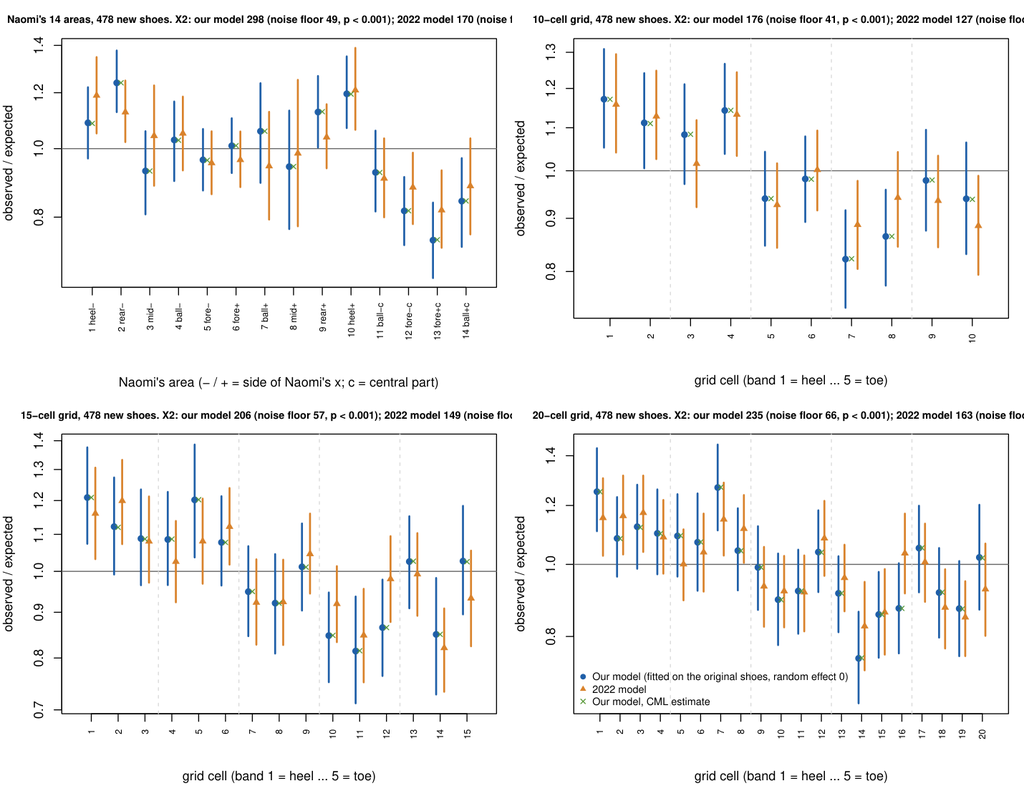

**Fig. 5. Observed / predicted with pointwise 95% bootstrap intervals, per part of the shoe.** Blue: our model; orange: the 2022 model; green ×: our model by CML. Panel titles give each partition's X² and noise floor (the long titles are cut at the right; all values are in the tables above). Areas are numbered as in Naomi's paper: "−" areas are on the right of the maps above and "+" areas on the left (area 10, "heel+", is the left heel area of Fig. 3); "c" marks the central areas. Grid cells run in five bands (dashed lines) from heel (1) to toe, and across the shoe within a band. `model_images/validation/new/part2_obs_exp_new.pdf`

On Naomi's areas our model under-predicts the rear and heel areas (2, 9, 10: 13–24% more RACs than predicted) and over-predicts the central ball and forefoot (12, 13, 14: 16–26% fewer). On the grids: above 1 in the two rear bands, lowest in band 4, back near 1 at the toe.

### Is the test itself right?

A simulation with the model true and no difference between collections: real shoe structure (60 original-like and 100 new-like shoes, with their own contact surfaces and RAC counts), 400 replicates.

- Pass. The goodness-of-fit test rejects a true model 5.2% of the time at the 5% level.
- Pass. The intervals that include the estimation error of the original fit are conservative (99.3–99.5% coverage).
- Fail. The log-score interval for the fitted surfaces (new shoes resampled only) covers 91% instead of 95%. Both log-score intervals in the table above, per RAC and per shoe, are therefore slightly too narrow.

The simulation checks the machinery in one setting, on a smaller original sample (Monte Carlo standard error of the 5.2% about 1.1 points), not every number. The fast refits of the original model it relies on were compared with full refits on 8 resamples only.

## Robustness checks

What this section is for: four questions a reviewer could raise, and the answers.

Four questions a reviewer is likely to ask, answered from the existing fits and bootstrap records.

### Are the new shoes on the same scale, and the same size?

The new images are smaller, but that is the frame, not the shoe. The decisive check uses the 67 soles printed in both collections: the same physical sole has the same size in pixels in both, so the scale is the same.

| Snake outline | Original (386) | New (631) | Same 67 soles: new / original |
| --- | --- | --- | --- |
| Length, median (10%–90%) | 311 px (302–317) | 314 px (306–319) | 1.013 (0.98–1.04) |
| Width, median (10%–90%) | 119 px (112–127) | 122 px (115–132) | 1.026 (0.95–1.08) |
| Outline perimeter, median | 700 px | 709 px | 1.021 (0.98–1.07) |

The shoes are the same size within 1–2.5% on average; for one sole, the two prints differ in length by up to 3–4% (10%–90% range), which shifts y by a few pixels at the toe and heel since y is not rescaled. This matters because the standardization rescales x but keeps the raw y: with equal lengths no length scaling is needed, and the reprinted soles line up in y with a median shift of 0 px. What is smaller on new shoes is the contact area inside the outline (−12%): less of the sole touches the paper. The new collection's own prototype is computed (the overlay of all 631 shoes, 34,509 px, and reproduced exactly from scratch) and used to clean the images.

### Does non-uniformity survive the dependence between RACs?

The Wald tests above treat RACs as independent. Resampling whole shoes (1,000 shoe-bootstrap refits of the fixed effects per collection, at the fitted σ²) gives a covariance that allows any dependence within a shoe. Uniformity is the hypothesis that all 24 spatial terms are 0, so the test is valid on any basis; the new fits here use the original knots, the common basis of the comparison.

| All 24 spatial terms = 0 (GLMM) | Model-based W | Shoe-bootstrap W | p (F(24, 976) reference) |
| --- | --- | --- | --- |
| Original, 386 shoes | 428.7 | 255.3 | < 10<sup>−16</sup> |
| New, 631 shoes (original knots) | 623.1 | 377.1 | < 10<sup>−16</sup> |
| New without reprints (original knots) | — | 311.4 | < 10<sup>−16</sup> |

The F reference is the Hotelling T² scaling for a covariance estimated from 1,000 draws; it allows for the Monte Carlo error of that covariance, not for the precision set by the number of shoes. With χ² or with F on the number of shoes the p-values are also far below 10<sup>−16</sup>. W drops by about 40% once the dependence is allowed for, and the conclusion does not move. The cluster-robust CML (Efron approximation) agrees: original 234.4, new 329.0.

### Do the knots matter?

The paper's basis has 3 knots across the shoe and 5 along it. Cross-validation by shoe (5 folds, CML fits; standard errors approximate) compares it with finer bases:

- **Original shoes:** no finer basis improves the held-out log score (z between −1.4 and +0.8), although the finest lowers held-out cell residuals away from the heel front.
- **New shoes:** the finest basis predicts better (z = 2.1) and removes most of the heel-front misfit (held-out observed/expected 0.64 → 0.92).
- **Goodness of fit with other bases for the original fit:** X² on Naomi's areas falls from 298 to 257 (finer basis along the shoe) and 281 (full tensor), still 1.5–1.7 times the 2022 model's 170; the log score stays level with the 2022 model. These fits have no bootstrap of their own, so no p-value is available, and a richer basis adds estimation error that would raise the noise floor. The rejection is very likely not an artefact of the paper's knots, but this is not shown formally.

This supports reporting a knot sensitivity analysis in the paper.

### Is the 2022 comparison fair?

Naomi's original `optim` call (Nelder-Mead) stops at its iteration limit, so its intensities are up to 9.8% from the optimum; this is immaterial for her conclusions (1.61 log-likelihood units). The goodness of fit does not use that call: the 2022 model is refitted by its exact conditional maximum likelihood (a Poisson GLM, converged) on our contact surface, within 9.4% per area of her converged estimates, and refitted again in every bootstrap resample. The comparison is therefore against a properly fitted 2022 model.

## Draft answer to the journal's Reviewer 1

What this section is for: the journal (Forensic Science International) asked us to revise the paper. Its Reviewer 1 asked, in point 1, what the paper adds beyond Naomi's 2022 paper, and in point 6, for validation on real out-of-sample data. The new shoes are that out-of-sample data. Below is a **first draft** of a paragraph for our response letter, written from the results above. It is not a result and not a decision: Micha and Naomi decide what we answer. In particular, its last sentences narrow what the paper claims, which only they can decide.

> We applied the model to a second collection of 631 shoe prints. About 67 of them appear to be reprints of soles in the original collection (to be confirmed); the validation set of 478 excludes these, uncertain matches and poor prints. The spatial non-uniformity of RAC locations replicates: it holds without the reprints and under a bootstrap that resamples whole shoes (p < 10<sup>−16</sup>). The surface fitted on the original collection transfers only partly. A goodness-of-fit test that accounts for the estimation error of the original fit rejects exact transfer (p < 0.001); the 2022 regional model, also rejected, fits the new prints' regional counts better, clearly on its own regions and borderline on independent grids, and the continuous surface's contrasts are too strong (calibration slope 0.70). The overall RAC density does not differ significantly between the collections (ratio 1.06, 95% CI 0.93–1.22). Per RAC, the continuous surface predicts the new RACs no better than the 2022 regional model. RACs within a shoe are not independent: pairs 2–8 pixels apart are 37% (new) and 45% (original) more frequent than independent placement predicts. We therefore present the model as a description of where single RACs tend to occur, not as a tool to compute the probability of a set of RACs. Because the collections differ in source, scanning and marking, the misfit may reflect a different population as much as model error; we discuss sole design and these differences as limitations.

## Open questions

What this section is for: decisions and facts we need from co-authors before the numbers are final.

| For | Question |
| --- | --- |
| Sarena, Yoram | Which new shoes are reprints of original shoes? This fixes the validation set. |
| Micha | Refit the model with the per-shoe offset? With it, σ² is 0.979 on the original shoes. |
| Micha, Naomi | Report a knot sensitivity analysis in the paper? |
| Micha, Naomi | The paper's Wald statistic: state which variance (RX or Hessian) it uses. |
| Naomi | Why `exp(−σ²/2)`? The expectation is `exp(+σ²/2)`; see `pixel analysis.R:364`. |
| Naomi | Rerun the 2022 estimator to convergence for the paper's table? |

## Appendix: further figures

What this section is for: extra figures that repeat or extend the ones above; not needed to follow the report.

These repeat or extend the figures above.

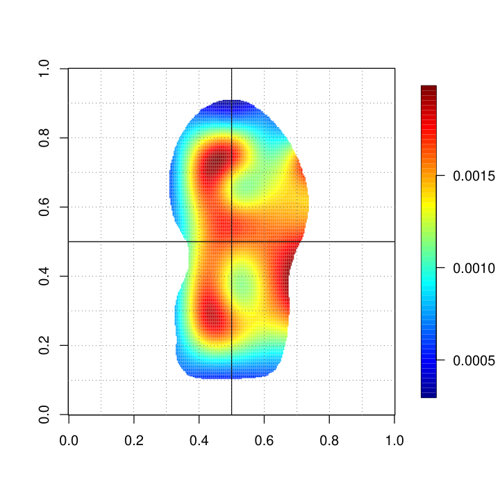

**Fig. A1a. Original shoes,** random effects on the standardized shoe, with coordinates. `model_images/NEW_X_NS_XY_SHOE.pdf`

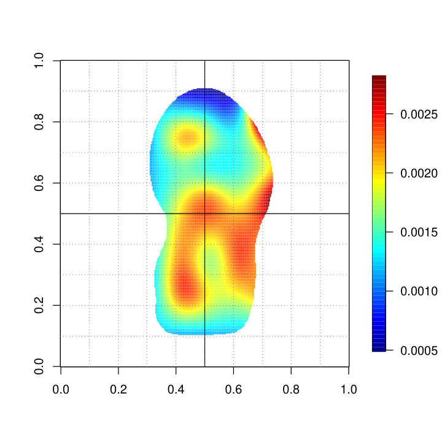

**Fig. A1b. New shoes,** the same map for the new collection. `model_images/new/NEW_X_NS_XY_SHOE_new.pdf`

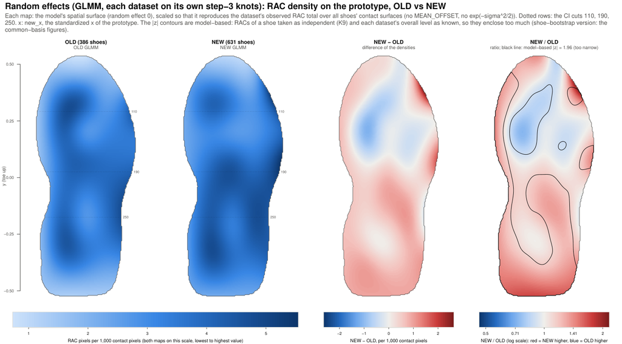

**Fig. A2. One absolute scale.** Each collection on its own knots. From left: original, new (same scale), new − original, new / original (red = new higher, blue = original higher; ratio panel only: the black line is a model-based |z| = 1.96, too narrow because it treats RACs as independent). Units: RAC pixels per 1,000 contact pixels, each map scaled to its observed total, so the level differs from Fig. 1. The internal labels in the header (K9, MEAN_OFFSET, step-3 knots) refer to this scaling and to the paper's basis. `model_images/compare/intensity_maps_glmm_old_vs_new.pdf`

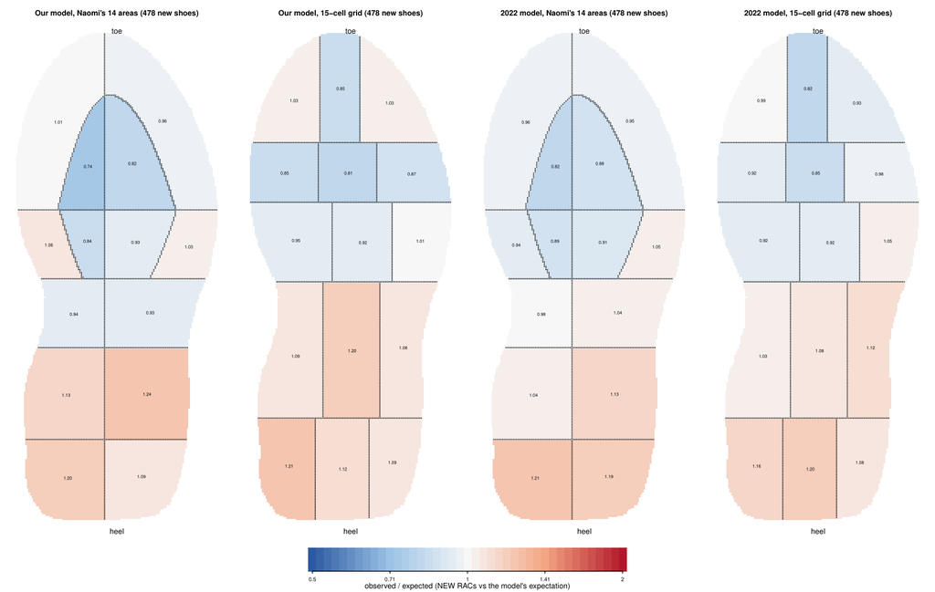

**Fig. A3. Our model and the 2022 model, 14 areas and 15 cells.** Observed / predicted (red: more than predicted; blue: fewer). From left: our model on the 14 areas and on 15 cells, the 2022 model on the 14 areas and on 15 cells. Primary set, 478 shoes. `model_images/validation/new/part2_cells_map_new.pdf`

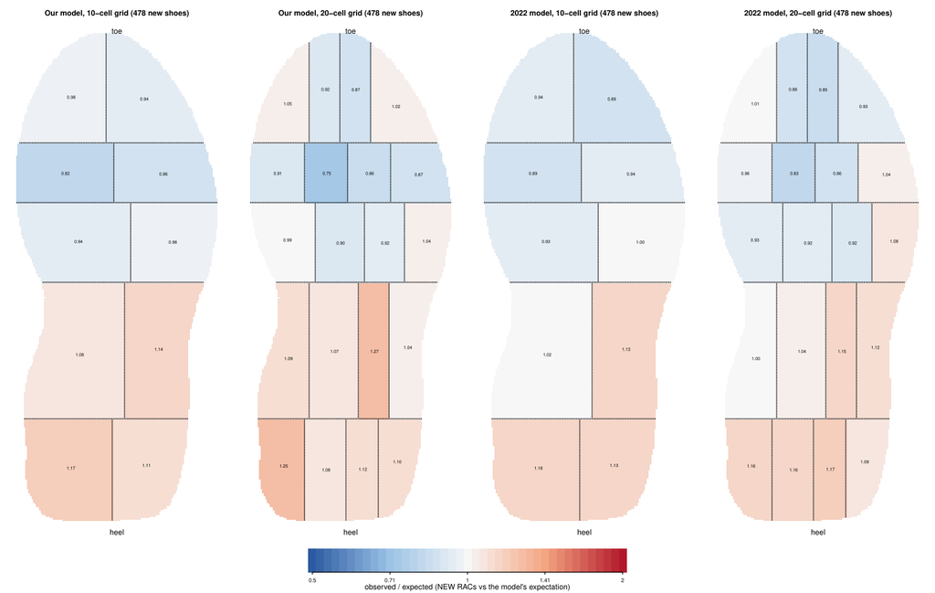

**Fig. A4. The 10- and 20-cell grids.** Observed / predicted (red: more than predicted; blue: fewer). From left: our model with 10 and 20 cells, the 2022 model with 10 and 20 cells. Primary set, 478 shoes. `model_images/validation/new/part2_cells_map_g20_new.pdf`

## How the work was done

What this section is for: the timeline, and how the work was checked.

[output not shown]

Details: `docs/progress/LOG.md`, `docs/decisions.md`, `docs/results/validation.md`, `docs/results/old-vs-new.md`.